# Plot The Iris Data

This second notebook uses the output from `001-read-and-format.Rmd`.

Sometimes, when you have a long analysis project, it is helpful to break it into several different files.

(Obviously this is short enough that it would be fine to do it all in one file. But that is not always the case—especially if you have multiple people working on different aspects of the analysis.)

We will be writing out some plots, so make sure to create a directory for them to go in:

```r
dir.create("outputs/002", showWarnings = FALSE, recursive = TRUE)
```

Read the formatted data output in 001 in here:

```r
library(tidyverse)  # always load libraries needed in the current script/notebook,
                    # even if they might already have been loaded in a previous
                    # notebook.  (i.e. in `001-read-and-format.Rmd`).

iris_data <- read_rds("outputs/001/dat_final.rds")
```

Now, I want to plot each length and width measurement against every other length and width measurement and colour the points by species. This can be done pretty easily by faceting with ggplot. But to do so, we need things in a different format, like this:

```r
iris_x <- pivot_longer(
  iris_data,
  cols = c(-indiv, -species),
  names_to = "measurement_x",
  values_to = "x"
)
iris_y <- pivot_longer(
  iris_data,
  cols = c(-indiv, -species),
  names_to = "measurement_y",
  values_to = "y"
)

iris_pairwise <- iris_x %>%
  left_join(iris_y, by = c("indiv", "species"))
```

Now, make the plot.

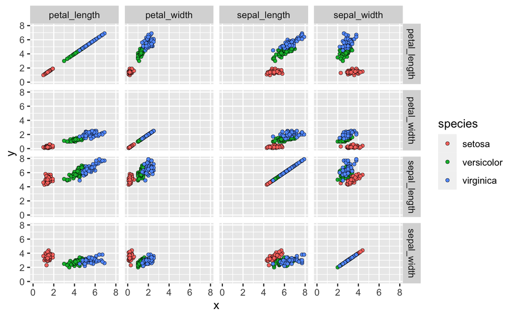

```r
g <- ggplot(iris_pairwise, aes(x = x, y = y, fill = species)) +
  geom_point(shape = 21, stroke = 0.2) +
  facet_grid(measurement_y ~ measurement_x)

g
```

That is a nice picture.

Now, if we wanted to write that figure out as a PDF file to be in high resolution, etc., we would write that out to the `outputs/002` directory.

```r
ggsave(
  g,
  filename = "outputs/002/faceted-plot.pdf",
  width = 10,
  height = 8
)
```

## Session Info

```r
if("sessioninfo" %in% rownames(installed.packages())) {
  sessioninfo::session_info()
} else {
  sessionInfo()
}
```

|  | setting | value |
| --- | --- | --- |
| version | version | R version 4.1.1 (2021-08-10) |
| os | os | macOS Mojave 10.14.6 |
| system | system | x86_64, darwin17.0 |
| ui | ui | RStudio |
| language | language | (EN) |
| collate | collate | en_US.UTF-8 |
| ctype | ctype | en_US.UTF-8 |
| tz | tz | America/Denver |
| date | date | 2021-12-29 |